# Milk Nutriention and Biomarker Assosition

# Introduction

This notebook aims to explore the associations between nutrients and bio-markers using milk samples as the dataset. We will employ two main techniques for analysis: correlation and regression. Correlation will help us identify potential relationships between nutrients and bio-markers, while regression will allow us to predict bio-marker concentrations based on nutrient levels.

```r
source("C:/Users/Parth Doshi/Dropbox/Nutrishield_Study_II_Project (ParthD thesis)/R-script/EDA_for_Human_Mother_Milk/Functions.R")
# install required Libraries
Libraies_requried <- c("tidyverse","caret","ggplot2","ggcorrplot","stats","psych","factoextra","FactoMineR","ranger","party")

check_and_install_libraries(Libraies_requried)
```

```
✖ psych::%+%()    masks ggplot2::%+%()
```

```r
# load Required Libraries
library(tidyverse)
library(caret)
library(ggplot2)
library(ggcorrplot)
library(stats)
library(psych)
library(factoextra)
library(FactoMineR)
library(ranger)
library(party)
```

# load Data sets

The data-sets include Short-chain Fatty Acids (SCFA), Qtrap Targeted and Semiquantitative Urinary Bio markers, Nutritional Data from Human Milk (HM) quality using (MIRIS), and Human Milk (HM) Fatty Acids (FAMES)

```r
NSII_SCFA_Urine <-  read.csv("C:/Users/Parth Doshi/Dropbox/Nutrishield_Study_II_Project (ParthD thesis)/NSII_Corrected_and_Clean_Data/NSII_SCFA_Urine.csv", sep = ",")
NSII_Qtrap_Targeted_Urine <-  read.csv("C:/Users/Parth Doshi/Dropbox/Nutrishield_Study_II_Project (ParthD thesis)/NSII_Corrected_and_Clean_Data/NSII_Qtrap_Targeted_Urine.csv", sep = ",")
NSII_Qtrap_Semiquant_Urine <-  read.csv("C:/Users/Parth Doshi/Dropbox/Nutrishield_Study_II_Project (ParthD thesis)/NSII_Corrected_and_Clean_Data/NSII_Qtrap_Semiquant_Urine.csv", sep = ",")
NSII_MIRIS_HM <-  read.csv("C:/Users/Parth Doshi/Dropbox/Nutrishield_Study_II_Project (ParthD thesis)/NSII_Corrected_and_Clean_Data/NSII_MIRIS_HM_Subset.csv", sep = ",")
NSII_FAMES_HM <-  read.csv("C:/Users/Parth Doshi/Dropbox/Nutrishield_Study_II_Project (ParthD thesis)/NSII_Corrected_and_Clean_Data/NSII_FAMES_HM_subset.csv", sep = ",")
```

### Data preparation

```r
# remove class unwanted Column from data frame
NSII_SCFA_Urine <- NSII_SCFA_Urine %>%
dplyr::select(-X,-Class,-Sample,-NewClass)

NSII_Qtrap_Targeted_Urine <- NSII_Qtrap_Targeted_Urine %>%
dplyr::select(-X,-Class,-Sample,-NewClass)

NSII_Qtrap_Semiquant_Urine <- NSII_Qtrap_Semiquant_Urine %>%
dplyr::select(-X,-Class,-Sample,-NewClass)

NSII_MIRIS_HM <- NSII_MIRIS_HM %>%
  dplyr::select(-c(1,2,3),-NewClass)

NSII_FAMES_HM <- NSII_FAMES_HM %>%
  dplyr::select(-c(1,2,3),-NewClass)


# edit some of typos in categorial  columns

NSII_MIRIS_HM$Month[NSII_MIRIS_HM$Month == "6.1"] <- "6"
NSII_MIRIS_HM$Month[NSII_MIRIS_HM$Month == "L2"] <- "6"
NSII_MIRIS_HM$Month[NSII_MIRIS_HM$Month == "2B"] <- "2"
NSII_MIRIS_HM$ID[NSII_MIRIS_HM$ID == "P07.6"] <- "P7"
NSII_MIRIS_HM$ID[NSII_MIRIS_HM$ID == "T54.1HM"] <- "T54"
NSII_FAMES_HM$Month[NSII_FAMES_HM$Month == "2B"] <- "2"
NSII_FAMES_HM$Month[NSII_FAMES_HM$Month == "R"] <- "RBW"
NSII_FAMES_HM$Month[NSII_FAMES_HM$Month == "C"] <- "CEN"
NSII_FAMES_HM$Month[NSII_FAMES_HM$Month == "2B"] <- "2"
NSII_Qtrap_Targeted_Urine$Type[NSII_Qtrap_Targeted_Urine$Type == "IU2"] <- "IU"
```

#### Removing features

Removed the features that predominantly consist of missing data, remain constant throughout, or dplyr::select those variable which show variation concerning months.

```r
# Targeted Biomarkers
NSII_Qtrap_Targeted_Urine <- NSII_Qtrap_Targeted_Urine %>%
  dplyr::select(ID,Month,Type,Phloretin,O.DMA,Hesperetin,L.Tyrosine,X1.Methylhistidine,X3.Methylhistidine,Gallic.Acid)

# SCFA
NSII_SCFA_Urine <- NSII_SCFA_Urine %>%
  dplyr::select(-Acetic)

# FAMES
NSII_FAMES_HM <- NSII_FAMES_HM %>%
  dplyr::select(-Undecanoate,-Tridecanoate,-Tricosanoate,-Heneicosanoate,-Docosanoate,-`cis.10.Pentadecenoic`,-`cis.11.14.17.Eicosatrienoic`)

# Semiquant Bio markers
# Calculate the percentage of missing values for each column
missing_percent <- colSums(NSII_Qtrap_Semiquant_Urine == 0 | NSII_Qtrap_Semiquant_Urine == 0.0) / nrow(NSII_Qtrap_Semiquant_Urine) * 100
# Get the names of columns with missing values exceeding 50%
missing_variables <- names(missing_percent[missing_percent > 50])
NSII_Qtrap_Semiquant_Urine <- NSII_Qtrap_Semiquant_Urine[, !names(NSII_Qtrap_Semiquant_Urine) %in% missing_variables]
```

#### Data Normalization

```r
# Scaling Data using Box-Cox transformation

NSII_SCFA_Urine_Scaled <- scale_data(NSII_SCFA_Urine)
NSII_Qtrap_Targeted_Urine_Scaled <- scale_data(NSII_Qtrap_Targeted_Urine)
NSII_Qtrap_Semiquant_Urine_Scaled <- scale_data(NSII_Qtrap_Semiquant_Urine)
NSII_MIRIS_HM_Scaled <- scale_data(NSII_MIRIS_HM)
NSII_FAMES_HM_Scaled <- scale_data(NSII_FAMES_HM)
```

#### spiting data Bio marker data set in Mother and Infants

```r
split_and_create_dataframes(NSII_SCFA_Urine_Scaled)
```

```
<environment: R_GlobalEnv>
```

```r
split_and_create_dataframes(NSII_Qtrap_Targeted_Urine_Scaled)
```

```
<environment: R_GlobalEnv>
```

```r
split_and_create_dataframes(NSII_Qtrap_Semiquant_Urine_Scaled)
```

```
<environment: R_GlobalEnv>
```

# Correlation

In this we will find correlation between Bio markers And nutrients based on Month

### SCFA VS MILK(MIRIS)

```r
library(gridExtra)

# merge SCFA and MILK DATA based on ID and MONTH
merge_SCFA_MIRIS_IU <- merge(NSII_MIRIS_HM_Scaled, NSII_SCFA_Urine_Scaled_IU, by = c("ID","Month"))
merge_SCFA_MIRIS_MU <- merge(NSII_MIRIS_HM_Scaled, NSII_SCFA_Urine_Scaled_MU, by = c("ID","Month"))

# Converting CEN AND RBW to 0 as they are consider Time 0
merge_SCFA_MIRIS_IU <- convert_month_to_zero(merge_SCFA_MIRIS_IU)
merge_SCFA_MIRIS_MU <- convert_month_to_zero(merge_SCFA_MIRIS_MU)

# split the Data set according to Month
split_and_create_dataframe_month(merge_SCFA_MIRIS_IU)
```

```
<environment: R_GlobalEnv>
```

```r
split_and_create_dataframe_month(merge_SCFA_MIRIS_MU)
```

```
<environment: R_GlobalEnv>
```

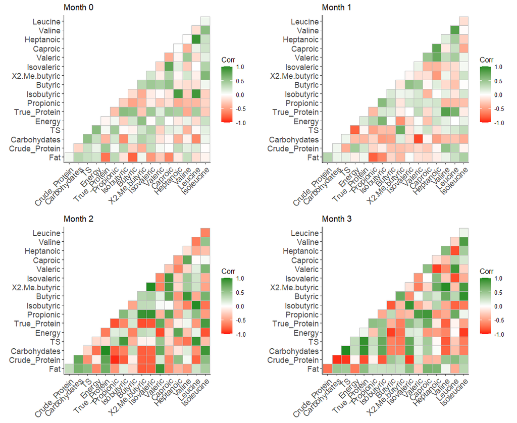

```r
# Plot Correlation for each month for infants

Plot_1 <- calculate_and_visualize_correlation(merge_SCFA_MIRIS_IU_0,"pearson","Month 0")
Plot_2 <- calculate_and_visualize_correlation(merge_SCFA_MIRIS_IU_1,"pearson","Month 1")
Plot_3 <- calculate_and_visualize_correlation(merge_SCFA_MIRIS_IU_2,"pearson","Month 2")
Plot_4 <- calculate_and_visualize_correlation(merge_SCFA_MIRIS_IU_3,"pearson","Month 3")

combined_plots <- grid.arrange(Plot_1,Plot_2,Plot_3,Plot_4, ncol = 2)
```

```r
print(combined_plots)
```

| z | cells | name | grob |
| --- | --- | --- | --- |
| 1 | (1-1,1-1) | arrange | gtable[layout] |
| 2 | (1-1,2-2) | arrange | gtable[layout] |
| 3 | (2-2,1-1) | arrange | gtable[layout] |
| 4 | (2-2,2-2) | arrange | gtable[layout] |

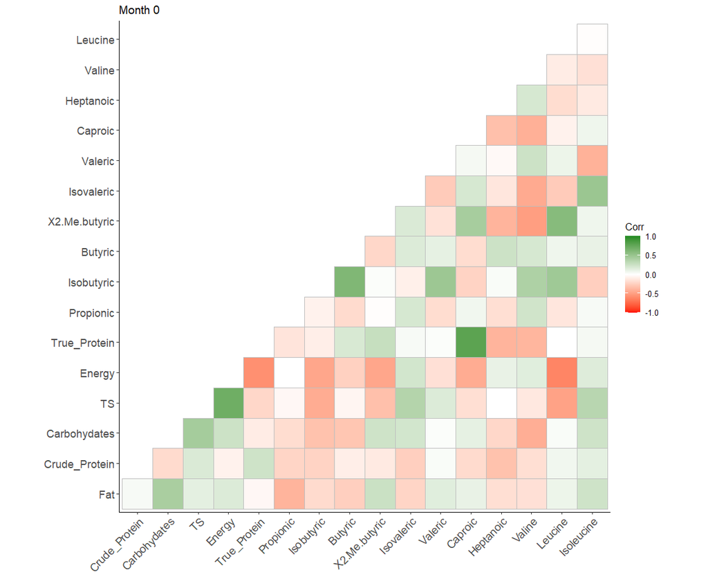

```r
ggsave("correlation_plot.png", combined_plots, dpi = 700, bg = "transparent")
# Plot Correlation for each month for Mothers
 calculate_and_visualize_correlation(merge_SCFA_MIRIS_MU_0,"pearson","Month 0")
```

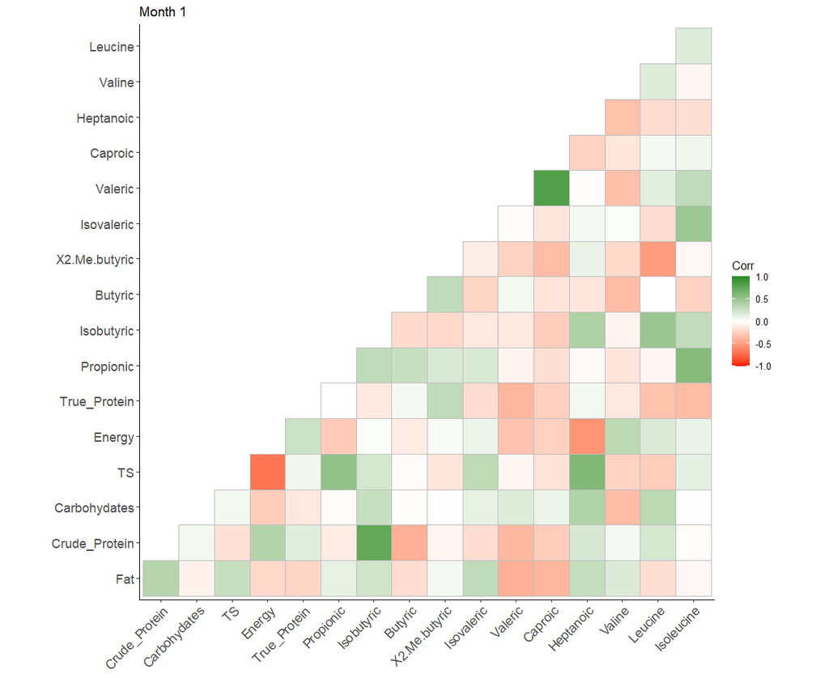

```r
 calculate_and_visualize_correlation(merge_SCFA_MIRIS_MU_1,"pearson","Month 1")
```

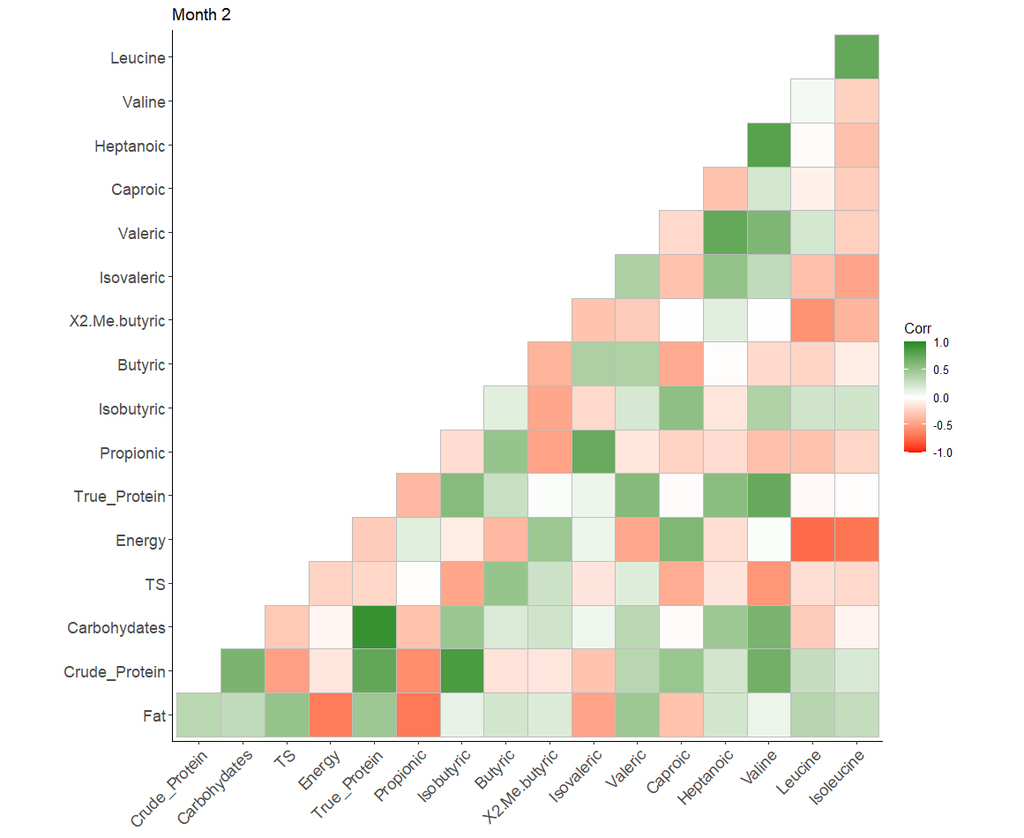

```r
 calculate_and_visualize_correlation(merge_SCFA_MIRIS_MU_2,"pearson","Month 2")
```

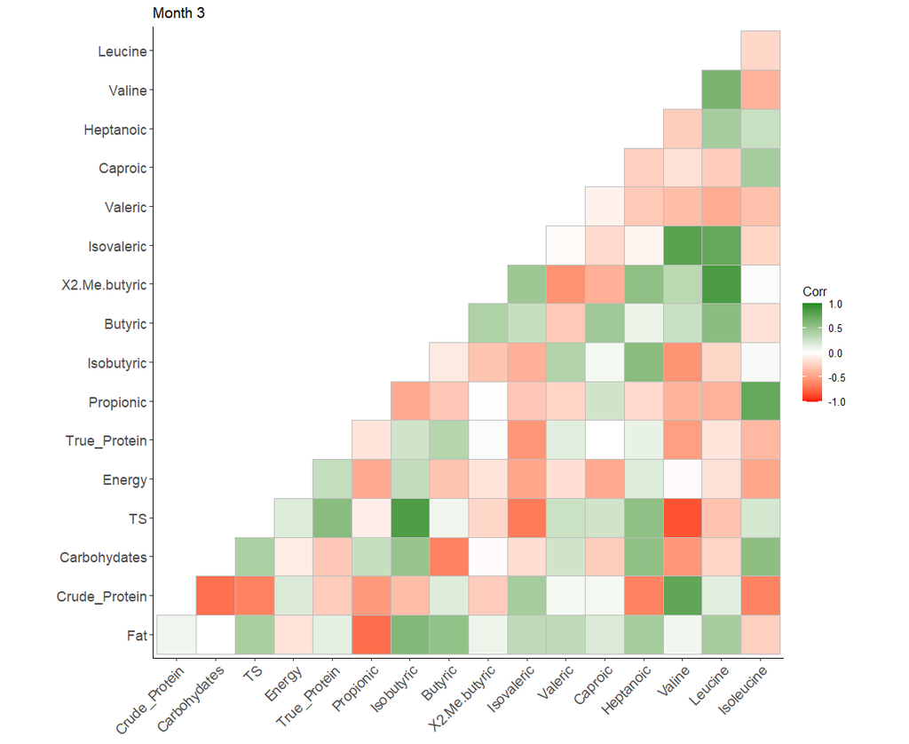

```r
 calculate_and_visualize_correlation(merge_SCFA_MIRIS_MU_3,"pearson","Month 3")
```

### SCFA VS Fatty Acids (FAMES)

```r
# merge SCFA and MILK DATA based on ID and MONTH
merge_SCFA_FAMES_IU <- merge(NSII_FAMES_HM_Scaled, NSII_SCFA_Urine_Scaled_IU, by = c("ID","Month"))
merge_SCFA_FAMES_MU <- merge(NSII_FAMES_HM_Scaled, NSII_SCFA_Urine_Scaled_MU, by = c("ID","Month"))

# Converting CEN AND RBW to 0 as they are consider Time 0
merge_SCFA_FAMES_IU <- convert_month_to_zero(merge_SCFA_FAMES_IU)
merge_SCFA_FAMES_MU <- convert_month_to_zero(merge_SCFA_FAMES_MU)

# split the Data set according to Month
split_and_create_dataframe_month(merge_SCFA_FAMES_IU)
split_and_create_dataframe_month(merge_SCFA_FAMES_MU)


# Plot Correlation for each month for infants

calculate_and_visualize_correlation(merge_SCFA_FAMES_IU_0,"pearson","correlation plot SCFA(Infants) VS MILK(FAMES) for Month 0")
calculate_and_visualize_correlation(merge_SCFA_FAMES_IU_1,"pearson","correlation plot SCFA(Infants) VS MILK(FAMES) for Month 1")
calculate_and_visualize_correlation(merge_SCFA_FAMES_IU_2,"pearson","correlation plot SCFA(Infants) VS MILK(FAMES) for Month 2")
 calculate_and_visualize_correlation(merge_SCFA_FAMES_IU_3,"pearson","correlation plot SCFA(Infants) VS MILK(FAMES) for Month 3")

# Plot Correlation for each month for Mothers

calculate_and_visualize_correlation(merge_SCFA_FAMES_MU_0,"pearson","correlation plot SCFA(Mother) VS MILK(FAMES) for Month 0 ")
 calculate_and_visualize_correlation(merge_SCFA_FAMES_MU_1,"pearson","correlation plot SCFA(Mother) VS MILK(FAMES) for Month 1")
calculate_and_visualize_correlation(merge_SCFA_FAMES_MU_2,"pearson","correlation plot SCFA(Mother) VS MILK(FAMES) for Month 2")
 calculate_and_visualize_correlation(merge_SCFA_FAMES_MU_3,"pearson","correlation plot SCFA(Mother) VS MILK(FAMES) for Month 3")
```

[output not shown]

#### Targeted bio markers vs MILK(miris)

```r
# merge Targeted Biomkers and MILK DATA based on ID and MONTH
merge_Targeted_MIRIS_IU <- merge(NSII_MIRIS_HM_Scaled, NSII_Qtrap_Targeted_Urine_Scaled_IU, by = c("ID","Month"))
merge_Targeted_MIRIS_MU <- merge(NSII_MIRIS_HM_Scaled, NSII_Qtrap_Targeted_Urine_Scaled_MU, by = c("ID","Month"))

# Converting CEN AND RBW to 0 as they are consider Time 0
merge_Targeted_MIRIS_IU <- convert_month_to_zero(merge_Targeted_MIRIS_IU)
merge_Targeted_MIRIS_MU <- convert_month_to_zero(merge_Targeted_MIRIS_MU)

# split the Data set according to Month
split_and_create_dataframe_month(merge_Targeted_MIRIS_IU)
split_and_create_dataframe_month(merge_Targeted_MIRIS_MU)


# Plot Correlation for each month for infants

calculate_and_visualize_correlation(merge_Targeted_MIRIS_IU_0,"pearson","correlation plot Targeted(Infants) VS MILK(MIRIS) for Month 0")
calculate_and_visualize_correlation(merge_Targeted_MIRIS_IU_1,"pearson","correlation plot Targeted(Infants) VS MILK(MIRIS) for Month 1")
calculate_and_visualize_correlation(merge_Targeted_MIRIS_IU_2,"pearson","correlation plot Targeted(Infants) VS MILK(MIRIS) for Month 2")
calculate_and_visualize_correlation(merge_Targeted_MIRIS_IU_3,"pearson","correlation plot Targeted(Infants) VS MILK(MIRIS) for Month 3")

# Plot Correlation for each month for Mothers

calculate_and_visualize_correlation(merge_Targeted_MIRIS_MU_0,"pearson","correlation plot Targeted(Mother) VS MILK(MIRIS) for Month 0 ")
calculate_and_visualize_correlation(merge_Targeted_MIRIS_MU_1,"pearson","correlation plot Targeted(Mother) VS MILK(MIRIS) for Month 1")
calculate_and_visualize_correlation(merge_Targeted_MIRIS_MU_2,"pearson","correlation plot Targeted(Mother) VS MILK(MIRIS) for Month 2")
calculate_and_visualize_correlation(merge_Targeted_MIRIS_MU_3,"pearson","correlation plot Targeted(Mother) VS MILK(MIRIS) for Month 3")
```

[output not shown]

#### Targeted bio-markers vs MILK(FAMES)

```r
# merge Targeted Biomkers and MILK DATA based on ID and MONTH
merge_Targeted_FAMES_IU <- merge(NSII_FAMES_HM_Scaled, NSII_Qtrap_Targeted_Urine_Scaled_IU, by = c("ID","Month"))
merge_Targeted_FAMES_MU <- merge(NSII_FAMES_HM_Scaled, NSII_Qtrap_Targeted_Urine_Scaled_MU, by = c("ID","Month"))

# Converting CEN AND RBW to 0 as they are consider Time 0
merge_Targeted_FAMES_IU <- convert_month_to_zero(merge_Targeted_FAMES_IU)
merge_Targeted_FAMES_MU <- convert_month_to_zero(merge_Targeted_FAMES_MU)

# split the Data set according to Month
split_and_create_dataframe_month(merge_Targeted_FAMES_IU)
split_and_create_dataframe_month(merge_Targeted_FAMES_MU)


# Plot Correlation for each month for infants

calculate_and_visualize_correlation(merge_Targeted_FAMES_IU_0,"pearson","correlation plot Targeted(Infants) VS MILK(FAMES) for Month 0")
calculate_and_visualize_correlation(merge_Targeted_FAMES_IU_1,"pearson","correlation plot Targeted(Infants) VS MILK(FAMES) for Month 1")
calculate_and_visualize_correlation(merge_Targeted_FAMES_IU_2,"pearson","correlation plot Targeted(Infants) VS MILK(FAMES) for Month 2")
calculate_and_visualize_correlation(merge_Targeted_FAMES_IU_3,"pearson","correlation plot Targeted(Infants) VS MILK(FAMES) for Month 3")

# Plot Correlation for each month for Mothers

calculate_and_visualize_correlation(merge_Targeted_FAMES_MU_0,"pearson","correlation plot Targeted(Mother) VS MILK(FAMES) for Month 0 ")
calculate_and_visualize_correlation(merge_Targeted_FAMES_MU_1,"pearson","correlation plot Targeted(Mother) VS MILK(FAMES) for Month 1")
calculate_and_visualize_correlation(merge_Targeted_FAMES_MU_2,"pearson","correlation plot Targeted(Mother) VS MILK(FAMES) for Month 2")
calculate_and_visualize_correlation(merge_Targeted_FAMES_MU_3,"pearson","correlation plot Targeted(Mother) VS MILK(FAMES) for Month 3")
```

[output not shown]

#### Semiquant bio-markers vs MILK(miris)

```r
# merge Semiquant Biomkers and MILK DATA based on ID and MONTH
merge_Semiquant_MIRIS_IU <- merge(NSII_MIRIS_HM_Scaled, NSII_Qtrap_Semiquant_Urine_Scaled_IU, by = c("ID","Month"))
merge_Semiquant_MIRIS_MU <- merge(NSII_MIRIS_HM_Scaled, NSII_Qtrap_Semiquant_Urine_Scaled_MU, by = c("ID","Month"))

# Converting CEN AND RBW to 0 as they are consider Time 0
merge_Semiquant_MIRIS_IU <- convert_month_to_zero(merge_Semiquant_MIRIS_IU)
merge_Semiquant_MIRIS_MU <- convert_month_to_zero(merge_Semiquant_MIRIS_MU)

# split the Data set according to Month
split_and_create_dataframe_month(merge_Semiquant_MIRIS_IU)
split_and_create_dataframe_month(merge_Semiquant_MIRIS_MU)


# Plot Correlation for each month for infants

calculate_and_visualize_correlation(merge_Semiquant_MIRIS_IU_0,"pearson","correlation plot Semiquant(Infants) VS MILK(MIRIS) for Month 0")
calculate_and_visualize_correlation(merge_Semiquant_MIRIS_IU_1,"pearson","correlation plot Semiquant(Infants) VS MILK(MIRIS) for Month 1")
calculate_and_visualize_correlation(merge_Semiquant_MIRIS_IU_2,"pearson","correlation plot Semiquant(Infants) VS MILK(MIRIS) for Month 2")
calculate_and_visualize_correlation(merge_Semiquant_MIRIS_IU_3,"pearson","correlation plot Semiquant(Infants) VS MILK(MIRIS) for Month 3")

# Plot Correlation for each month for Mothers

calculate_and_visualize_correlation(merge_Semiquant_MIRIS_MU_0,"pearson","correlation plot Semiquant(Mother) VS MILK(MIRIS) for Month 0")
calculate_and_visualize_correlation(merge_Semiquant_MIRIS_MU_1,"pearson","correlation plot Semiquant(Mother) VS MILK(MIRIS) for Month 1")
calculate_and_visualize_correlation(merge_Semiquant_MIRIS_MU_2,"pearson","correlation plot Semiquant(Mother) VS MILK(MIRIS) for Month 2")
calculate_and_visualize_correlation(merge_Semiquant_MIRIS_MU_3,"pearson","correlation plot Semiquant(Mother) VS MILK(MIRIS) for Month 3")
```

[output not shown]

#### Semiquant bio markers vs MILK(FAMES)

```r
# merge Semiquant Biomkers and MILK DATA based on ID and MONTH
merge_Semiquant_FAMES_IU <- merge(NSII_FAMES_HM_Scaled, NSII_Qtrap_Semiquant_Urine_Scaled_IU, by = c("ID","Month"))
merge_Semiquant_FAMES_MU <- merge(NSII_FAMES_HM_Scaled, NSII_Qtrap_Semiquant_Urine_Scaled_MU, by = c("ID","Month"))

# Converting CEN AND RBW to 0 as they are consider Time 0
merge_Semiquant_FAMES_IU <- convert_month_to_zero(merge_Semiquant_FAMES_IU)
merge_Semiquant_FAMES_MU <- convert_month_to_zero(merge_Semiquant_FAMES_MU)

# split the Data set according to Month
split_and_create_dataframe_month(merge_Semiquant_FAMES_IU)
split_and_create_dataframe_month(merge_Semiquant_FAMES_MU)


# Plot Correlation for each month for infants

calculate_and_visualize_correlation(merge_Semiquant_FAMES_IU_0,"pearson","correlation plot Semiquant(Infants) VS MILK(FAMES) for Month 0")
calculate_and_visualize_correlation(merge_Semiquant_FAMES_IU_1,"pearson","correlation plot Semiquant(Infants) VS MILK(FAMES) for Month 1")
calculate_and_visualize_correlation(merge_Semiquant_FAMES_IU_2,"pearson","correlation plot Semiquant(Infants) VS MILK(FAMES) for Month 2")
calculate_and_visualize_correlation(merge_Semiquant_FAMES_IU_3,"pearson","correlation plot Semiquant(Infants) VS MILK(FAMES) for Month 3")

# Plot Correlation for each month for Mothers

calculate_and_visualize_correlation(merge_Semiquant_FAMES_MU_0,"pearson","correlation plot Semiquant(Mother) VS MILK(FAMES) for Month 0 ")
calculate_and_visualize_correlation(merge_Semiquant_FAMES_MU_1,"pearson","correlation plot Semiquant(Mother) VS MILK(FAMES) for Month 1")
calculate_and_visualize_correlation(merge_Semiquant_FAMES_MU_2,"pearson","correlation plot Semiquant(Mother) VS MILK(FAMES) for Month 2")
calculate_and_visualize_correlation(merge_Semiquant_FAMES_MU_3,"pearson","correlation plot Semiquant(Mother) VS MILK(FAMES) for Month 3")
```

[output not shown]

# Regression

In this study, we will employ a Multiple Regression model to predict the levels of Short-Chain Fatty Acids (SCFA) using Milk data, specifically MIRIS and FAMES, from various months. The primary objective is to develop a predictive model that can estimate SCFA levels in different months based on data collected from other months. By establishing such a model, we aim to explore the potential relationships between Milk components and SCFA levels and investigate whether these relationships hold true across different time periods.

## MILK (MIRIS)

#### Regression model for Month 0

```r
library(Metrics)
# Regression model for Month 1
# remove Categorical variable
merge_SCFA_MIRIS_IU_0_new <- merge_SCFA_MIRIS_IU_0 %>%
  dplyr::select(-Month,-Type,-ID,)
merge_SCFA_MIRIS_IU_1_new <- merge_SCFA_MIRIS_IU_0 %>%
  dplyr::select(-Month,-Type,-ID,)
merge_SCFA_MIRIS_IU_2_new <- merge_SCFA_MIRIS_IU_0 %>%
  dplyr::select(-Month,-Type,-ID,)
merge_SCFA_MIRIS_IU_3_new <- merge_SCFA_MIRIS_IU_0 %>%
  dplyr::select(-Month,-Type,-ID,)


# Split the data into training (70%) and testing (30%) sets
train_index <- sample(1:nrow(merge_SCFA_MIRIS_IU_0_new), 0.7 * nrow(merge_SCFA_MIRIS_IU_0_new))
train_data <- merge_SCFA_MIRIS_IU_0_new[train_index, ]
test_data <- merge_SCFA_MIRIS_IU_0_new[-train_index, ]



# Create a matrix of the dependent variables (SCFAs)
scfa_matrix <- train_data %>%
  dplyr::select(7:17)
scfa_matrix <- as.matrix(scfa_matrix)

# Build the multiple linear regression model
model_miris_IU_0 <- lm(scfa_matrix ~ Fat + Crude_Protein + True_Protein, data = train_data)
summary(model_miris_IU_0)

# Make predictions on the test data using the model
predictions <- predict(model_miris_IU_0, newdata = test_data)
# RMSE Values
model_stat_0 <- calculate_mse_and_rmse(test_data,predictions)
print(" rmse values for month 0")
print(model_stat_0$rmse)

# # Make predictions on the month 1 data using the model of month 0
prediction_month_1 <- predict(model_miris_IU_0, merge_SCFA_MIRIS_IU_1_new)
model_stat_0_1 <- calculate_mse_and_rmse(merge_SCFA_MIRIS_IU_1_new,prediction_month_1)
print(" rmse values for month 1")
print(model_stat_0_1$rmse)

# # Make predictions on the month 2 data using the model of month 0
prediction_month_2 <- predict(model_miris_IU_0, merge_SCFA_MIRIS_IU_2_new)
model_stat_0_2 <- calculate_mse_and_rmse(merge_SCFA_MIRIS_IU_2_new,prediction_month_2)
print(" rmse values for month 2")
print(model_stat_0_2$rmse)

# # Make predictions on the month 3 data using the model of month 0
prediction_month_3 <- predict(model_miris_IU_0, merge_SCFA_MIRIS_IU_3_new)
model_stat_0_3 <- calculate_mse_and_rmse(merge_SCFA_MIRIS_IU_3_new,prediction_month_3)
print(" rmse values for month 3")
print(model_stat_0_3$rmse)
```

[output not shown]

#### Regression model for Month 1

```r
# Split the data into training (70%) and testing (30%) sets
train_index_1 <- sample(1:nrow(merge_SCFA_MIRIS_IU_1_new), 0.7 * nrow(merge_SCFA_MIRIS_IU_1_new))
train_data_1 <- merge_SCFA_MIRIS_IU_0_new[train_index_1, ]
test_data_1 <- merge_SCFA_MIRIS_IU_0_new[-train_index_1, ]

scfa_matrix_1 <- train_data_1 %>%
  dplyr::select(7:17)
scfa_matrix_1 <- as.matrix(scfa_matrix_1)

# Build the multiple linear regression model
model_miris_IU_1 <- lm(scfa_matrix_1 ~ Fat + Crude_Protein + True_Protein + Carbohydates , data = train_data_1)
summary(model_miris_IU_1)

# Make predictions on the test data using the model
predictions_1 <- predict(model_miris_IU_1, newdata = test_data_1)
model_stat_1 <- calculate_mse_and_rmse(test_data_1,predictions_1)
print(" rmse values for month 1")
print(model_stat_1$rmse)

# Make predictions on the month 2 data using the model of month 1
prediction_month_1_2 <- predict(model_miris_IU_1, merge_SCFA_MIRIS_IU_2_new)
# Calculate the Mean Squared Error (MSE) for each SCFA
model_stat_1_2 <- calculate_mse_and_rmse(merge_SCFA_MIRIS_IU_2_new,prediction_month_1_2)
print(" rmse values for month 2")
print(model_stat_1_2$rmse)

# Make predictions on the month 3 data using the model of month 1
prediction_month_1_3 <- predict(model_miris_IU_1, merge_SCFA_MIRIS_IU_3_new)
# Calculate the Mean Squared Error (MSE) for each SCFA
model_stat_1_3 <- calculate_mse_and_rmse(merge_SCFA_MIRIS_IU_3_new,prediction_month_1_3)
print(" rmse values for month 3")
print(model_stat_1_3$rmse)
```

[output not shown]

#### Regression model for Month 2

```r
# Split the data into training (70%) and testing (30%) sets
train_index_2 <- sample(1:nrow(merge_SCFA_MIRIS_IU_2_new), 0.7 * nrow(merge_SCFA_MIRIS_IU_2_new))
train_data_2 <- merge_SCFA_MIRIS_IU_0_new[train_index_2, ]
test_data_2 <- merge_SCFA_MIRIS_IU_0_new[-train_index_2, ]

scfa_matrix_2 <- train_data_2 %>%
  dplyr::select(7:17)

scfa_matrix_2 <- as.matrix(scfa_matrix_2)

# Build the multiple linear regression model
model_miris_IU_2 <- lm(scfa_matrix_2 ~ Fat + Crude_Protein + True_Protein + Carbohydates , data = train_data_1)
summary(model_miris_IU_2)

# Make predictions on the test data using the model
predictions_2 <- predict(model_miris_IU_2, newdata = test_data_2)
# Calculate the Mean Squared Error (MSE) for each SCFA
model_stat_2 <- calculate_mse_and_rmse(test_data_2,predictions_2)
print(" rmse values for month 2")
print(model_stat_2$rmse)

# Make predictions on the month 3 using the model for month 2
prediction_month_2_3 <- predict(model_miris_IU_1, merge_SCFA_MIRIS_IU_3_new)
# Calculate the Mean Squared Error (MSE) for each SCFA
model_stat_2_3 <- calculate_mse_and_rmse(merge_SCFA_MIRIS_IU_2_new,prediction_month_2_3)
print(" rmse values for month 3")
print(model_stat_2_3$rmse)
```

[output not shown]

## MILK (FAMES)

regression using milk fatty acids to predict Short chain fatty acids

### Feature selection using carat as there to select fatty acids

##### Using correlation method

```r
# month 0 (RBW and CEN)
Corr_SCFA_FAMES_IU_0 <- cor(merge_SCFA_FAMES_IU_0[3:34])
highlycorrelareated_0 <- findCorrelation(Corr_SCFA_FAMES_IU_0, cutoff = 0.75)
# Get the names of highly correlated variables for month 0
highlycorrelated_names_0 <- colnames(merge_SCFA_FAMES_IU_0[3:34][, highlycorrelareated_0])
print("Month 0")
print(highlycorrelated_names_0)

# month 1
Corr_SCFA_FAMES_IU_1 <- cor(merge_SCFA_FAMES_IU_1[3:42])
highlycorrelareated_1 <- findCorrelation(Corr_SCFA_FAMES_IU_1, cutoff = 0.75)
highlycorrelated_names_1 <- colnames(merge_SCFA_FAMES_IU_1[3:42][, highlycorrelareated_1])
print("Month 1")
print(highlycorrelated_names_1)

# month 2
Corr_SCFA_FAMES_IU_2 <- cor(merge_SCFA_FAMES_IU_2[3:42])
highlycorrelareated_2 <- findCorrelation(Corr_SCFA_FAMES_IU_2, cutoff = 0.75)
highlycorrelated_names_2 <- colnames(merge_SCFA_FAMES_IU_2[3:42][, highlycorrelareated_2])
print("Month 2")
print(highlycorrelated_names_2)

# month 3
Corr_SCFA_FAMES_IU_3 <- cor(merge_SCFA_FAMES_IU_3[3:42])
highlycorrelareated_3 <- findCorrelation(Corr_SCFA_FAMES_IU_3, cutoff = 0.75)
highlycorrelated_names_3 <- colnames(merge_SCFA_FAMES_IU_3[3:42][, highlycorrelareated_3])
print("Month 3")
print(highlycorrelated_names_3)
```

[output not shown]

#### Using intrinsic method (glmnet) for feature selection

###### Feature selection Method for month 0

```r
set.seed(12345)

# Remove the fatty acids which show high correlation
merge_SCFA_FAMES_IU_0 <- merge_SCFA_FAMES_IU_0 %>% dplyr::select(-cis.5.8.11.14.17.Eicosapentaenoic,-Stearate,-Hexanoate, -cis.10.Heptadecenoic,-Myristate,-Heptanoic,-Myristoleate,-cis.11.14.Eicosadienoic,-ID,-Month,-Type)


# Feature selection using glmnet method

SCFA_name <- colnames(merge_SCFA_FAMES_IU_0[23:32])
# Loop through each SCFA
for (scfa in SCFA_name) {
  glmnet <- train(as.formula(paste(scfa, "~ .")),
                  data = merge_SCFA_FAMES_IU_0,
                  method = 'glmnet',
                  metric = "MAE")

  # Compute variable importance
  impVar <- varImp(glmnet)

  # Create variable importance plot using ggplot
 # Create variable importance plot using ggplot
  vi_plot <- ggplot(impVar, aes(x = variable, y = Overall, label = scfa)) +
    geom_bar(stat = "identity", fill = "#53cfff", width = 0.50 ) +
    theme_light(base_size = 20) +
    theme(axis.title.x = element_text(size = 15, colour = "black"),
          axis.title.y = element_blank(),
          axis.text.x = element_text(size = 15, colour = "black"),
          axis.text.y = element_text(size = 15, colour = "black")) +
    ggtitle(paste("Variable importance for", scfa))


  # Print the variable importance plot
  print(vi_plot)
}
```

[output not shown]

##### Regression for Month 0

```r
set.seed(123)  # For reproducibility
FAMES_index_0 <- sample(1:nrow(merge_SCFA_FAMES_IU_0), 0.7 * nrow(merge_SCFA_FAMES_IU_0))
FAMES_train_data_0 <- merge_SCFA_FAMES_IU_0[FAMES_index_0, ]
FAMES_test_data_0 <- merge_SCFA_FAMES_IU_0[-FAMES_index_0, ]


scfa_matrix_0 <- merge_SCFA_FAMES_IU_0 %>%
  dplyr::dplyr::select(23:32)
scfa_matrix_0 <- as.matrix(scfa_matrix_0)

install.packages("HH")
library(HH)
Propionic_model <- lm(Propionic ~ gamma.Linolenic + Nervonic.acid + Octanoate + Lignocerate ,data = merge_SCFA_FAMES_IU_0 )
summary(Propionic_model)
lmplot(Propionic_model)
Butyric_model <- lm(Butyric ~ Arachidonic + Eicosanoic +  cis.11.Eicosenoic + Erucic.acid +  Palmitate + Palmitoleate + Octanoate + Linoleic + Heptadecanoate ,data = merge_SCFA_FAMES_IU_0)
summary(Butyric_model)

X2_Me_butyric_model <- lm(X2.Me.butyric ~ Arachidonic + Nervonic.acid +  cis.11.Eicosenoic + Erucic.acid +  Palmitate + Palmitoleate + Linoleic + cis.8.11.14.Eicosatrienoic + cis.4.7.10.13.16.19.Docosahexaenoic + Pentadecanoate+Decanoate + Laurate ,data = merge_SCFA_FAMES_IU_0)
summary(X2_Me_butyric_model)


Isovaleric_model <- lm(Isovaleric ~ gamma.Linolenic + Nervonic.acid + Octanoate + Arachidonic + cis.11.Eicosenoic + Linoleic ,data = merge_SCFA_FAMES_IU_0)
summary(Isovaleric_model)

Valeric_model <- lm(Valeric ~  Elaidic + Palmitoleate+ Linoleic + Eicosanoic + Linolelaidic + Linolenic + Oleic + Laurate, data = merge_SCFA_FAMES_IU_0)
summary(Valeric_model)


Caporic_model <- lm(Caproic ~ Nervonic.acid + Lignocerate + Arachidonic + cis.11.Eicosenoic + Linoleic + Eicosanoic + Octanoate + Octanoate , data = merge_SCFA_FAMES_IU_0)
summary(Caporic_model)


Valine_model <- lm(Caproic ~ gamma.Linolenic + Arachidonic + Nervonic.acid +  cis.11.Eicosenoic + Linoleic + Eicosanoic ,data = merge_SCFA_FAMES_IU_0)
summary(Valine_model)
```

[output not shown]

###### Feature selection Method for month 1

```r
# Remove the fatty acids which show high correlation
merge_SCFA_FAMES_IU_1 <- merge_SCFA_FAMES_IU_1 %>% dplyr::select(-ID,-Month,-Type,-Octanoate, -Laurate, -Arachidonic, -Eicosanoic, -Myristoleate, -Myristate, -Elaidic, cis.13.16.Docosadienoic, -Heptanoic, -gamma.Linolenic, -Oleic, -Hexanoate, -cis.11.Eicosenoic, -Stearate, -Nervonic.acid, -Heptadecanoate, -Palmitate, -Linolenic )


# Feature selection using glmnet method

# Loop through each SCFA
for (scfa in SCFA_name) {
  formula <- as.formula(paste(scfa, "~ Decanoate+Pentadecanoate+Palmitoleate+cis.10.Heptadecenoic + Linoleic+Linolelaidic+cis.11.14.Eicosadienoic+cis.8.11.14.Eicosatrienoic+cis.5.8.11.14.17.Eicosapentaenoic+Erucic.acid+cis.13.16.Docosadienoic+cis.4.7.10.13.16.19.Docosahexaenoic+Lignocerate"))
  glmnet <- train(formula,
                  data = merge_SCFA_FAMES_IU_1,
                  method = 'glmnet',
                  metric = "MAE")

  # Compute variable importance
  impVar <- varImp(glmnet)

  # Create variable importance plot using ggplot
  # Create variable importance plot using ggplot
  vi_plot <- ggplot(impVar, aes(x = variable, y = Overall, label = scfa)) +
    geom_bar(stat = "identity", fill = "#53cfff", width = 0.50 ) +
    theme_light(base_size = 20) +
    theme(axis.title.x = element_text(size = 15, colour = "black"),
          axis.title.y = element_blank(),
          axis.text.x = element_text(size = 15, colour = "black"),
          axis.text.y = element_text(size = 15, colour = "black")) +
    ggtitle(paste("Variable importance for", scfa))


  # Print the variable importance plot
  print(vi_plot)
}
```

[output not shown]

###### Feature selection Method for month 2